# Projekt Eksploracja Danych

Michał Szulierz

2023-04-01

## Heart Attack Analysis & Prediction Dataset

Zbiór danych zawiera dane dotyczące pacjentów, którzy zostali poddani badaniom diagnostycznym związanym z chorobami serca.

1. Wiek - wiek pacjenta w latach
2. Plec - płeć pacjenta (0 - kobieta, 1 - mężczyzna)
3. Typ_bólu - typ bólu w klatce piersiowej (0 - typ nietypowy, 1 - typ wybuchowy, 2 - typ nieprawidłowy, 3 - typ stabilny)
4. Ciśnienie_krwi - ciśnienie krwi w spoczynku (w mm Hg)
5. Cholesteror - poziom cholesterolu w surowicy (w mg/dl)
6. Cukier - poziom cukru we krwi na czczo (> 120 mg/dl = 1, 0 w przeciwnym razie)
7. Wynik_EKG - wynik elektrokardiogramu podczas spoczynku (0 - norma, 1 - odchylenie ST-T, 2 - hipertrofia lewej komory)
8. Tętno - maksymalne osiągnięte tętno
9. Dławica_Piersiowa - dławica piersiowa spowodowana wysiłkiem (0 - nie, 1 - tak)
10. spadek_odcinka_ST - spadek odcinka ST wywołany wysiłkiem fizycznym względem spoczynku
11. Nachylenie - nachylenie odcinka ST podczas wysiłku (0 - brak, 1 - nachylenie w górę, 2 - nachylenie w dół)
12. Liczba_Naczyń - liczba głównych naczyń krwionośnych (0-3) zabarwionych podczas fluoroskopii
13. defekt - rodzaj defektu (0 - brak, 1 - odwrócony, 2 - normalny, 3 - odwrócony z niedoborem)
14. Choroba_Serca - wartość docelowa, określająca obecność choroby serca (0 - brak choroby, 1 - obecność choroby)

### Dane

| Wiek | Plec | Typ_bólu | Ciśnienie_krwi | Cholesterol | Cukier | Wynik_EKG | Tętno | Dławica_Piersiowa | spadek_odcinka_ST | nachylenie | Liczba_Naczyń | defekt | Choroba_Serca |
| --- | --- | --- | --- | --- | --- | --- | --- | --- | --- | --- | --- | --- | --- |
| 63 | 1 | 3 | 145 | 233 | 1 | 0 | 150 | 0 | 2.3 | 0 | 0 | 1 | 1 |
| 37 | 1 | 2 | 130 | 250 | 0 | 1 | 187 | 0 | 3.5 | 0 | 0 | 2 | 1 |
| 41 | 0 | 1 | 130 | 204 | 0 | 0 | 172 | 0 | 1.4 | 2 | 0 | 2 | 1 |
| 56 | 1 | 1 | 120 | 236 | 0 | 1 | 178 | 0 | 0.8 | 2 | 0 | 2 | 1 |
| 57 | 0 | 0 | 120 | 354 | 0 | 1 | 163 | 1 | 0.6 | 2 | 0 | 2 | 1 |
| 57 | 1 | 0 | 140 | 192 | 0 | 1 | 148 | 0 | 0.4 | 1 | 0 | 1 | 1 |
| 56 | 0 | 1 | 140 | 294 | 0 | 0 | 153 | 0 | 1.3 | 1 | 0 | 2 | 1 |
| 44 | 1 | 1 | 120 | 263 | 0 | 1 | 173 | 0 | 0.0 | 2 | 0 | 3 | 1 |
| 52 | 1 | 2 | 172 | 199 | 1 | 1 | 162 | 0 | 0.5 | 2 | 0 | 3 | 1 |
| 57 | 1 | 2 | 150 | 168 | 0 | 1 | 174 | 0 | 1.6 | 2 | 0 | 2 | 1 |
| 54 | 1 | 0 | 140 | 239 | 0 | 1 | 160 | 0 | 1.2 | 2 | 0 | 2 | 1 |
| 48 | 0 | 2 | 130 | 275 | 0 | 1 | 139 | 0 | 0.2 | 2 | 0 | 2 | 1 |
| 49 | 1 | 1 | 130 | 266 | 0 | 1 | 171 | 0 | 0.6 | 2 | 0 | 2 | 1 |
| 64 | 1 | 3 | 110 | 211 | 0 | 0 | 144 | 1 | 1.8 | 1 | 0 | 2 | 1 |
| 58 | 0 | 3 | 150 | 283 | 1 | 0 | 162 | 0 | 1.0 | 2 | 0 | 2 | 1 |
| 50 | 0 | 2 | 120 | 219 | 0 | 1 | 158 | 0 | 1.6 | 1 | 0 | 2 | 1 |
| 58 | 0 | 2 | 120 | 340 | 0 | 1 | 172 | 0 | 0.0 | 2 | 0 | 2 | 1 |
| 66 | 0 | 3 | 150 | 226 | 0 | 1 | 114 | 0 | 2.6 | 0 | 0 | 2 | 1 |
| 43 | 1 | 0 | 150 | 247 | 0 | 1 | 171 | 0 | 1.5 | 2 | 0 | 2 | 1 |
| 69 | 0 | 3 | 140 | 239 | 0 | 1 | 151 | 0 | 1.8 | 2 | 2 | 2 | 1 |
| 59 | 1 | 0 | 135 | 234 | 0 | 1 | 161 | 0 | 0.5 | 1 | 0 | 3 | 1 |
| 44 | 1 | 2 | 130 | 233 | 0 | 1 | 179 | 1 | 0.4 | 2 | 0 | 2 | 1 |
| 42 | 1 | 0 | 140 | 226 | 0 | 1 | 178 | 0 | 0.0 | 2 | 0 | 2 | 1 |
| 61 | 1 | 2 | 150 | 243 | 1 | 1 | 137 | 1 | 1.0 | 1 | 0 | 2 | 1 |
| 40 | 1 | 3 | 140 | 199 | 0 | 1 | 178 | 1 | 1.4 | 2 | 0 | 3 | 1 |
| 71 | 0 | 1 | 160 | 302 | 0 | 1 | 162 | 0 | 0.4 | 2 | 2 | 2 | 1 |
| 59 | 1 | 2 | 150 | 212 | 1 | 1 | 157 | 0 | 1.6 | 2 | 0 | 2 | 1 |
| 51 | 1 | 2 | 110 | 175 | 0 | 1 | 123 | 0 | 0.6 | 2 | 0 | 2 | 1 |
| 65 | 0 | 2 | 140 | 417 | 1 | 0 | 157 | 0 | 0.8 | 2 | 1 | 2 | 1 |
| 53 | 1 | 2 | 130 | 197 | 1 | 0 | 152 | 0 | 1.2 | 0 | 0 | 2 | 1 |

[output cut: 273 more lines]

### Braki Danych

```
## [1] 0
```

Braki Danych nie występują

## Wizualizacje

### Płeć Pacjentów

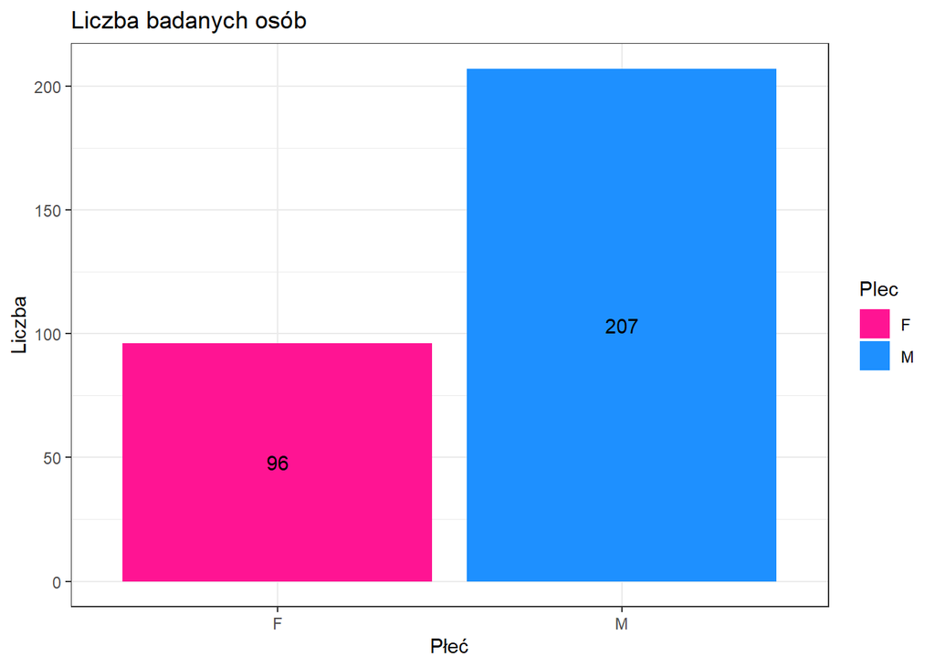

W Zbiorze danych mamy 96 kobiet oraz 207 mężczyzn.

### Poziom Cholesterolu

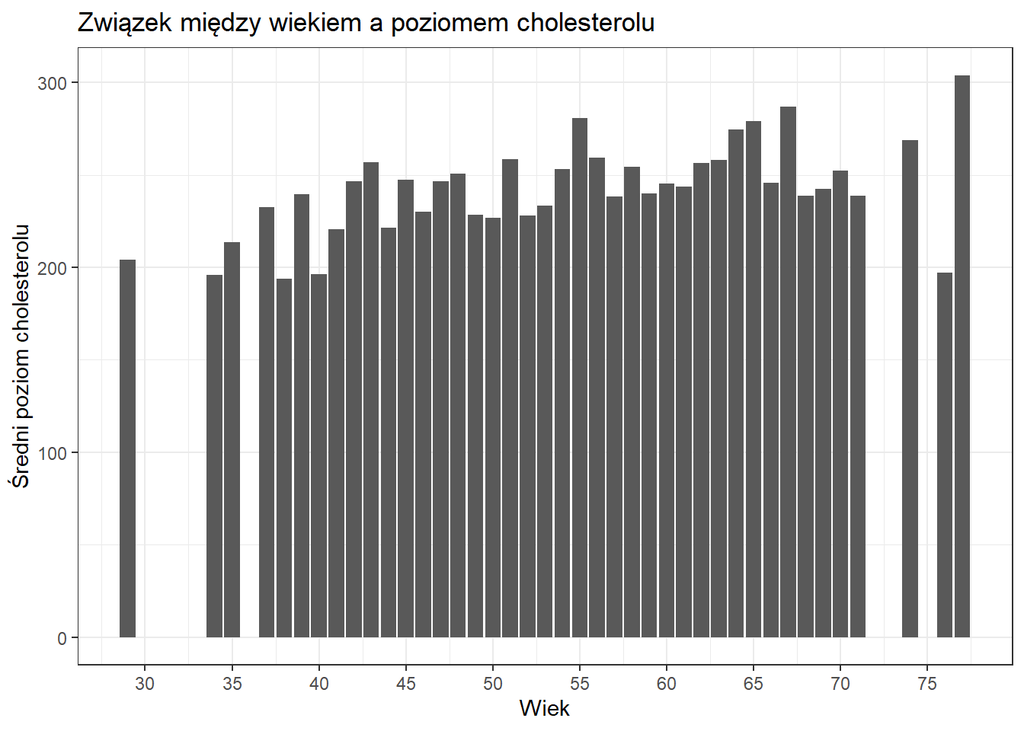

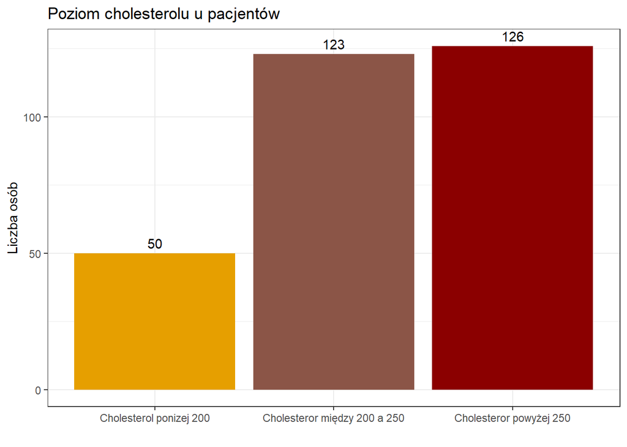

Cholesterol całkowity u zdrowego człowieka nie powinien przekraczać `200 mg/dl`. Jedynie u 50 pacjentów Cholesterol jest w normie. U 123 pacjentów Cholesterol jest na poziomie podwyższonym. 126 pacjentów ma Cholesterol znacznie podwyższony.

### Średnia wieku

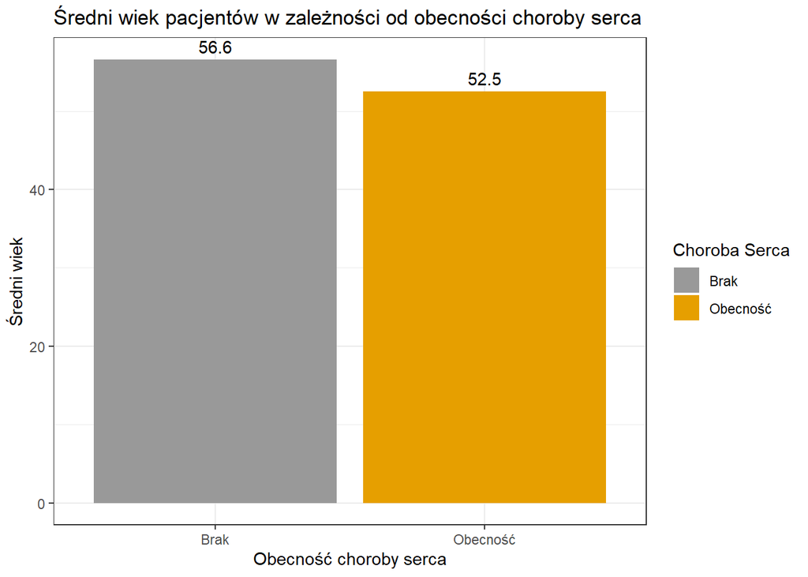

### Typ bólu oraz Ciśnienie Krwi

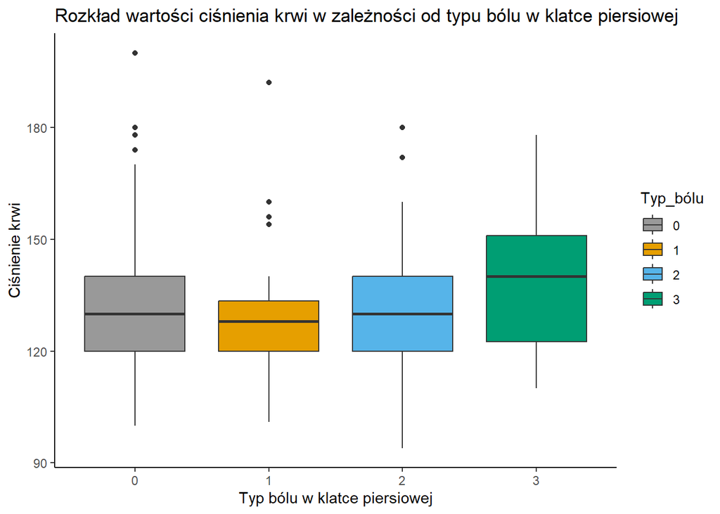

### Obecność Choroby serca a tętno

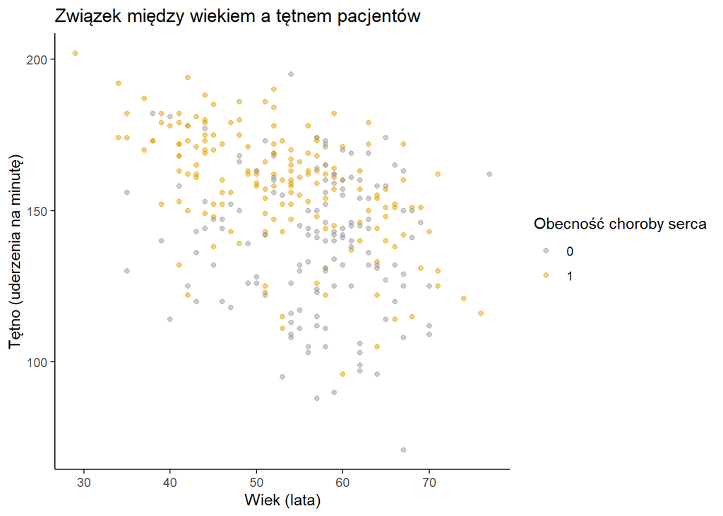

## Drzewo decyzyjne

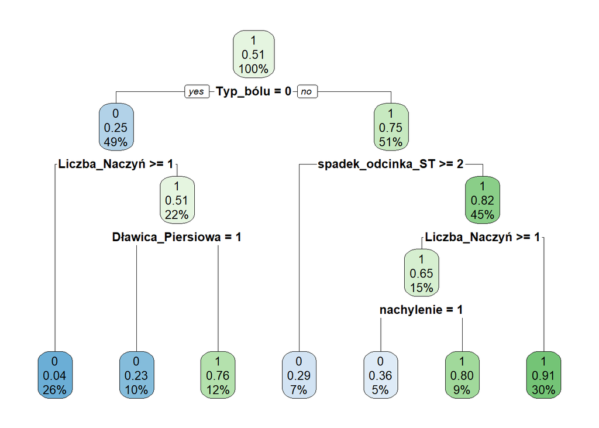

# Metoda `k` najbliższych sąsiadów